# Ejercicios Tema 3 - Distribuciones Notables: más distribuciones notables

Ricardo Alberich, Juan Gabriel Gomila y Arnau Mir

Curso de Probabilidad y Variables Aleatorias con R y Python

# Distribuciones Notables: más distribuciones notables.

## **Ley de Bendford**

La ley de Benford es una curiosa distribución de probabilidad que suele aparecer en la distribución del primer dígito de las cantidades registradas en contabilidades y en observaciones científicas o datos numéricos. La variable $X$ sigue una distribución discreta Benford con dominio $D_X=\{1,2,3,4,5,7,8,9\}$ son 9 dígitos (se elimina el cero) y sin función de probabilidad es
$$P_X(x)=P(X=x)=\log(d+1)-\log(d).$$

- 1. Calcular la media y la varianza de $X$.
- 2. Calcular la función de distribución de $X$.
- 3. ¿Cuál es el dígito más frecuente (moda)?
- 4. Construid con R las funciones de probabilidad y de distribución de $X$.
- 5. Dibujar con R las funciones del apartado anterior.

### Solución

1. Recordad que en R `log10` es el logartimo en base 10

Como $\log(d+1)-\log(d)=\log(\frac{d+1}{d})$. Podemos implementar la función de probabilidad de Bendford con el siguiente código R

```r
dBendford = function(x){
  sapply(x, FUN=function(x1)
  {
    if (x1 %in% 1:9)
    {log10(x1+1)-log10(x1)}
    else{0}
  })
}

dBendford(1:9)
```

```
## [1] 0.30103000 0.17609126 0.12493874 0.09691001 0.07918125 0.06694679
## [7] 0.05799195 0.05115252 0.04575749
```

```r
sum(dBendford(1:9))
```

```
## [1] 1
```

Así la media $\mu$ será

```r
mu=sum(c(1:9)*dBendford(1:9))
mu
```

```
## [1] 3.440237
```

```r
sumx2=sum(c(1:9)^2*dBendford(1:9))
sumx2
```

```
## [1] 17.89174
```

```r
sigma2=sumx2-mu^2
sigma2
```

```
## [1] 6.056513
```

```r
sigma=sqrt(sigma2)
sigma
```

```
## [1] 2.460998
```

En resumen La variable de Bendford tiene dominio $D_X=\{1,2,3,4,5,6,7,8,9\}$ y función de probabilidad

$$P_X(x)=P(X=x)=\left\{
\begin{array}{ll}
0.30103 & \mbox{si } x=1\\
0.1760913 & \mbox{si } x=2\\
0.1249387 & \mbox{si } x=3\\
0.09691 & \mbox{si } x=4\\
0.0791812 & \mbox{si } x=5\\
0.0669468 & \mbox{si } x=6\\
0.0579919 & \mbox{si } x=7\\
0.0511525 & \mbox{si } x=8\\
0.0457575 & \mbox{si } x=9\\
0 & \mbox{ en otro caso}
\end{array}
\right.$$

$$\begin{eqnarray*}
E(X) &=& \sum_{k=1}^9 x\cdot P_X(x)= 1 \cdot 0.30103+ 2 \cdot 0.1760913+3 \cdot 0.1249387+4 \cdot 0.09691+5 \cdot 0.0791812\\
&+& 6 \cdot 0.0669468+ 7 \cdot 0.0579919+ 8 \cdot 0.0511525+9 \cdot 0.0457575\\
&=& 3.440237
\end{eqnarray*}$$

Y por último $Var(X)=E(X^2)-(E(X))^2=17.891743-(3.440237)^2=6.0565126$ y la desviación tçípica es $\sqrt{Var(X)}=2.4609983.$

2. Ahora nos piden $F_X(x)=P(X\leq x)$. Con R es

```r
pBendford=function(x){
  sapply(x,FUN=function(x){
  probs=cumsum(dBendford(1:9))
  xfloor=floor(x)
  if(xfloor<1){0} else {if(xfloor>8) {1} else {probs[xfloor]}}
})
}

pBendford(0:9)
```

```
##  [1] 0.0000000 0.3010300 0.4771213 0.6020600 0.6989700 0.7781513 0.8450980
##  [8] 0.9030900 0.9542425 1.0000000
```

```r
pBendford(0)
```

```
## [1] 0
```

```r
pBendford(10)
```

```
## [1] 1
```

Así tenemos que

$$F_X(x)=P(X\leq x)=\left\{
\begin{array}{ll}
0 & \mbox{si } x<1\\
0.30103 & \mbox{si } 1\leq x < 2\\
0.4771213 & \mbox{si } 2\leq x < 3\\
0.60206 & \mbox{si } 3\leq x < 4\\
0.69897 & \mbox{si } 4\leq x < 5\\
0.7781513 & \mbox{si } 5\leq x < 6\\
0.845098 & \mbox{si } 6\leq x < 7\\
0.90309 & \mbox{si } 7\leq x < 8\\
0.9542425 & \mbox{si } 8\leq x < 9\\
1 & \mbox{si } 9\leq x
\end{array}
\right.$$
c) EL dígito más frecuente es el 1

```r
dBendford(1:9)
```

```
## [1] 0.30103000 0.17609126 0.12493874 0.09691001 0.07918125 0.06694679
## [7] 0.05799195 0.05115252 0.04575749
```

```r
max(dBendford(1:9))
```

```
## [1] 0.30103
```

```r
which.max(dBendford(1:9))
```

```
## [1] 1
```

4. Ya lo hemos hecho….
5. Dibujemos

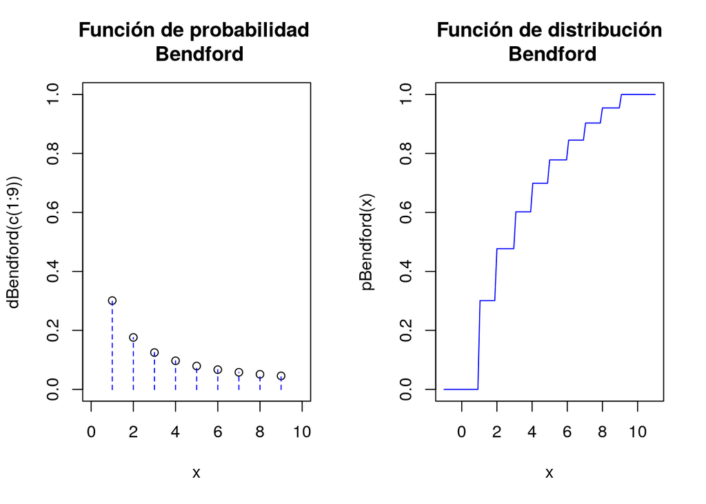

```r
par(mfrow=c(1,2))
aux=rep(0,18)
aux[seq(2,18,2)]=dBendford(c(1:9))
x=c(1:9)
plot(x,y=dBendford(c(1:9)),
  ylim=c(0,1),xlim=c(0,10),xlab="x",
  main="Función de probabilidad \n Bendford")
lines(x=rep(1:9,each=2),y=aux, type = "h", lty = 2,col="blue")
curve(pBendford(x), xlim=c(-1,11),col="blue", main="Función de distribución\n Bendford")
```

```r
par(mfrow=c(1,1))
```

## **Distribución de Pareto** (**Power law**)

Es una distribución que aparece en muchos ámbitos. Consideremos el económico. Supongamos que en un gran país consideramos la población activa económicamente; desde el más humilde becario al directivo más adinerado.

Escogemos un individuo al azar de esta población y observamos la variable $X=$ sus ingresos en euros (digamos que anuales).

Un modelo razonable es el que supone que:

- Hay un ingreso mínimo $x_m>0$.
- La probabilidad de un ingreso mayor que $x$ decrece de forma inversamente proporcional al ingreso $x$, es decir proporcional a $\left(\frac{x_m}{x}\right)^{\gamma}$ para algún número real $\gamma >1.$

Maś formalmente. dado $x>x_m$

$$P(X>x)=k\cdot \left(\frac{x_m}{x}\right)^{\gamma}.$$
Luego su función de distribución es

$$F_X(X)=P(X\leq x)=\left\{
\begin{array}{ll}
1-P(X > x)= 1- k\cdot \left(\frac{x_m}{x}\right)^{\gamma} & \mbox{ si } x>x_m\\
0 & \mbox{ si } x\leq x_m
\end{array}
\right.$$
Se pide

- 1. Calcular en función de $k$ y $\gamma$ la densidad de la variable $X$.
- 2. Para $\gamma>1$ calcular $E(X)$ y $Var(X)$ y su desviación típica.
- 3. ¿Qué sucede con $E(X)$ si $0<\gamma<1$.
- 4. ¿Cómo se calcula está [distribución con R](https://www.rdocumentation.org/packages/EnvStats/versions/2.3.1/topics/Pareto) [y con python](https://docs.scipy.org/doc/scipy/reference/generated/scipy.stats.Pareto.html)?
- 5. Dibujar las gráficas de su densidad y distribución para $\gamma=3$ y $\gamma=5$.
- 6. Explorar por internet (wikipedia) cómo es la distribución **power law** y qué relación tiene el concepto de *scale free* con los resultados del apartado c).

### Solución

1. La densididad será la derivada de la distribución $F_X$ respecto de $x$ , si $x\geq x_m>0$

$$\begin{eqnarray*}
f_X(x)=(F_X(x))'&=& \left(1- k\cdot \left(\frac{x_m}{x}\right)^{\gamma}\right)'=
\left(1- k\cdot x_m^{\gamma} \cdot x^{-\gamma} \right)'= \left(1- k\cdot x_m^{\gamma} \cdot x^{-\gamma} \right)'\\
&=& -\gamma\cdot(-k\cdot x_m^{\gamma}) \cdot x^{-\gamma-1}=\gamma\cdot k\cdot x_m^{\gamma} \cdot x^{-\gamma-1}
\end{eqnarray*}$$
Si tenemos $x<x_m$ entonces $f_X(x)=0$ en resumen

$$f_X(x)=\left\{
\begin{array}{ll}
\gamma \cdot x_m^{\gamma} \cdot x^{-\gamma-1} &\mbox{ si } x\geq x_m\\
0 &\mbox{ si } x< x_m\\
\end{array}
\right.$$
Notemos que $\gamma$ es un parámetro pero $k$ es na constante a determinar pues la densidad debe integrar 1 en el dominio $D_X=[x_m,\+\infty)$

$$\begin{eqnarray*}
\int_{x_m}^{+\infty} f_X(x) dx &=&\int_{x_m}^{+\infty} \gamma\cdot k\cdot x_m^{\gamma} \cdot x^{-\gamma-1}\cdot dx=\left[- k\cdot x_m^{\gamma} \cdot x^{-\gamma}\right]_{x=x_m}^{+\infty}= \lim_{x\to \infty} \left[- k\cdot x_m^{\gamma} \cdot x^{-\gamma}\right] - \left(- k\cdot x_m^{\gamma} \cdot x_m^{-\gamma}\right)\\
&=&
0 + k\cdot x_m^{\gamma} \cdot x_m^{-\gamma}=k.$
\end{eqnarray*}$$

Notemos que el límite es $0$ pues $\gamma>0$ y $x_>xM>0$. Luego $k=1$ y la función de densidad y la de distribución se puede escribir como damos dos versiones

$$f_X(x)=\left\{
\begin{array}{ll}
\gamma\cdot x_m^{\gamma} \cdot x^{-(\gamma+1)} &\mbox{ si } x\geq x_m\\
0 &\mbox{ si } x< x_m\\
\end{array}
\right.=
\left\{
\begin{array}{ll}
\frac{\gamma\cdot x_m^{\gamma}}{x^{(\gamma+1)}} &\mbox{ si } x\geq x_m\\
0 &\mbox{ si } x< x_m\\
\end{array}
\right.$$

$$f_X(x)=\left\{
\begin{array}{ll}
\gamma\cdot x_m^{\gamma} \cdot x^{-(\gamma+1)} &\mbox{ si } x\geq x_m\\
0 &\mbox{ si } x< x_m\\
\end{array}
\right.=
\left\{
\begin{array}{ll}
\frac{\gamma\cdot x_m^{\gamma}}{x^{(\gamma+1)}} &\mbox{ si } x\geq x_m\\
0 &\mbox{ si } x< x_m\\
\end{array}
\right.$$

y la distribución

$$F_X(X)=
\left\{
\begin{array}{ll}
1- x_m^\gamma \cdot x^{-\gamma} & \mbox{ si } x>x_m\\
0 & \mbox{ si } x\leq x_m
\end{array}
\right.
=\left\{
\begin{array}{ll}
1- \left(\frac{x_m}{x}\right)^{\gamma} & \mbox{ si } x>x_m\\
0 & \mbox{ si } x\leq x_m
\end{array}
\right.$$

Calculemos su esperanza

$$\begin{eqnarray*}
E(X)&=&\int_{x_m}^{+\infty} x\cdot f_X(x)\cdot dx=
\int_{x_m}^{+\infty} x\cdot \gamma\cdot x_m^{\gamma} \cdot x^{-\gamma-1}\cdot dx=
\int_{x_m}^{+\infty} \gamma\cdot x_m^{\gamma} \cdot x^{-\gamma}\cdot dx=
\left[\frac{\gamma}{-\gamma+1}\cdot x_m^{\gamma} \cdot x^{-\gamma+1}\right]_{x=x_m}^{+\infty}
\\
&=& \lim_{x\to \infty} \left[\frac{\gamma}{-\gamma+1}\cdot x_m^{\gamma} \cdot x^{-\gamma+1}\right] - \left(\frac{\gamma}{-\gamma+1} \cdot x_m^{\gamma} \cdot x_m^{-\gamma+1}\right)=
\lim_{x\to \infty} \left[\frac{\gamma}{-\gamma+1}\cdot x_m^{\gamma} \cdot x^{-\gamma+1}\right] + \frac{\gamma\cdot x_m}{\gamma-1}
\end{eqnarray*}$$

Así que **no siempre existe** $E(X)$, si en una distribución pareto $\gamma\leq 1$ su media diverge se dice entonces que es una distribución **de escala libre**, en inglés **scale free** en el sentido de que carece de media.

## **Distribución de Gumbel (teoría del valor extremo)**.

La distribución de Gumbel aparece en variables que miden lo que se llama un valor extremo: precipitación máxima de lluvia, tiempo máximo transcurrido entre dos terremotos, o en métodos de machine learning el máximo de las puntuaciones de una algoritmo; por ejemplo comparar pares de objetos (fotos, proteínas, etc.).

Una variable aleatoria sigue una ley de distribución Gumbel (de TIPO I) si su distribución es:

$$F_X(x)=\left\{
\begin{array}{ll}
e^{-e^{-\frac{x-\mu}{\beta}}} & \mbox{si} x\geq 0\\
0 & \mbox{si} x< 0\\
\end{array}
\right.$$

Para $\mu$ y $\beta>0$ parámetros reales. Llamaremos distribución Gumbel estándar a la que tiene por parámetros $\mu=0$ y $\beta=1.$

- 1. Si $X$ es una Gumbel estándar calcular su función de densidad y dibujar su gráfica.
- 2. Consideremos la función $F(x)=e^{-e^{-x}}$ para $x\geq 0$ y que vale cero en el resto de casos. Comprobar que es la función de distribución $P(X\leq x)$ de una v.a. Gumbel estándar.
- 3. Buscad un paquete de R que implemente la distribución Gumbel. Aseguraros de que es la (Gumbel Tipo I). Dejando fijo el parámetro $\beta=1$ dibujar la densidad Gumbel para varios valores de $\mu$ y explicad en que afecta a la gráfica el cambio de $\mu$.
- 4. Dejando fijo el parámetro $\mu$ dibujad la densidad Gumbel para varios valores de $\beta>0$ y explicar en que afecta a la gráfica el cambio de este parámetro.
- 5. Buscad cuales son las fórmulas de la esperanza y varianza de una distribución Gumbel en función de $\alpha$ y $\beta$.
- 6. Repetid los apartados c) y d) con python. Con python se puede pedir con la correspondiente función la esperanza y varianza de esta distribución, comprobar con esta función para algunos valores las fórmulas de la esperanza y la varianza del apartado e).